# 二月第四周

2018年 三月 04日

## 一、清醒时间安排情况

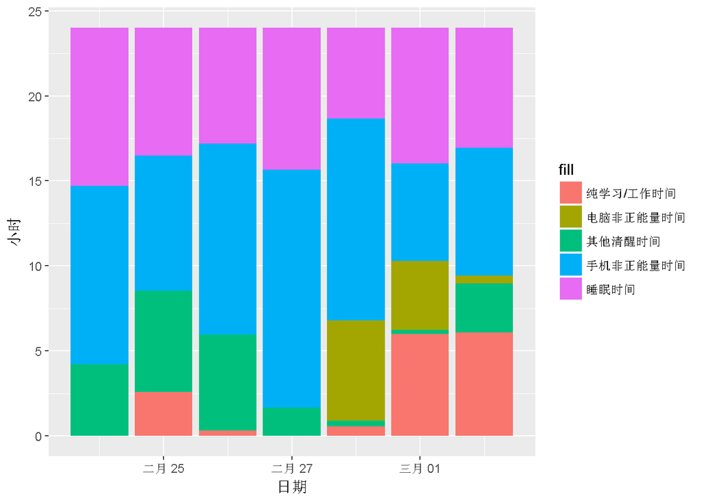

图中反映了本期7天每日时间的构成及其变化情况

启动时间，反映了本人自起床开始到做本日第一件事，平均要花1.75小时，占全部清醒时间的10.58%。

纯学习时间，平均为2.22小时，占清醒时间比重为13.42%。

手机非正能量时间每天为9.82小时,占清醒时间比重为59.46%。

电脑非正能量时间平均每天为1.49小时,占清醒时间比重为8.99%。

## 二、睡眠状况

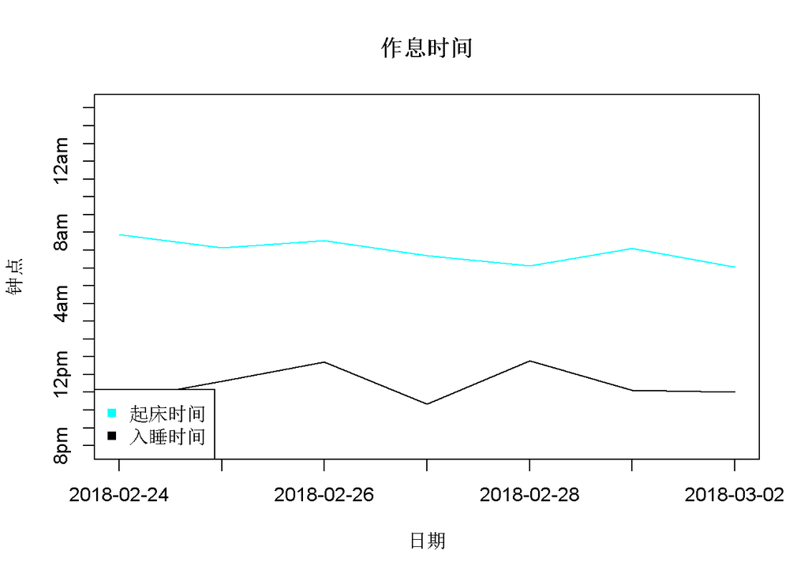

“作息时间”图反映了本期本人每日的入睡与起床时间，在这一期间，本人平均每天11点27分入睡，6点56分起床，睡眠时间平均为7.48小时。

入睡时间与起床时间没有显著的相关关系，相较而言，起床时间的波动要比入睡时间更小。

从线性趋势上看，总睡眠时间趋向减少，深睡眠时间趋向减少，睡眠质量向减少发展。

## 三、学习状况

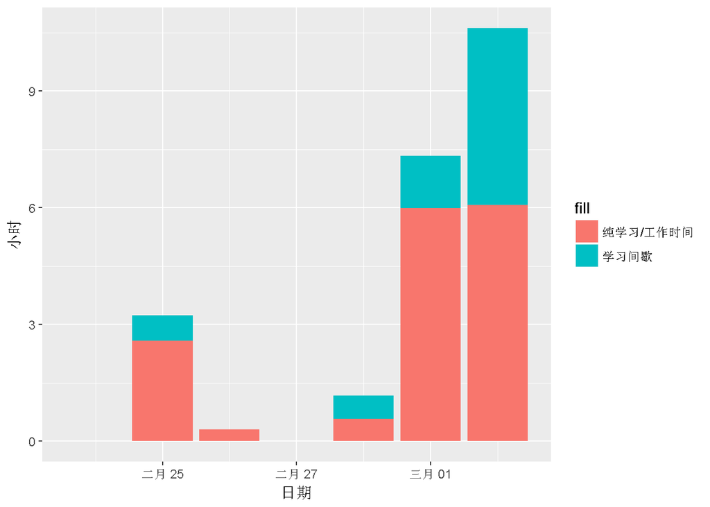

本期平均每日毛学习时间/工作时间为3.24小时，呈增加趋势。

纯学习时间/工作时间为2.22小时，呈增加趋势，用于学习的时间达到了平均水平。

时间利用比为1.46，学习态度需要做出改进。

### 核心时间

核心时间指的是完全由自主学习构成，推动复习进度的时间；最近一周的核心时间为11.58小时，占纯学习时间的75%。

就最近一个月而言，最近一周核心时间达到了平均水平。

就今年而言，最近一周用于核心学习的时间达到了平均水平。

## 四、娱乐时间

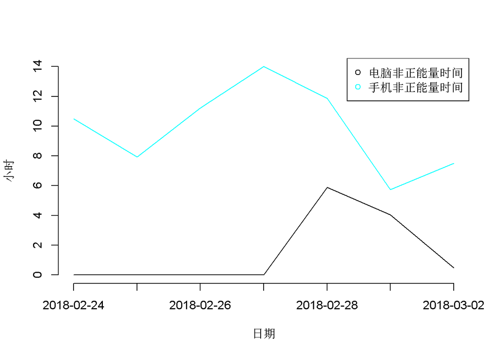

平均每日使用手机时间为10.31小时，呈减少趋势；其中非正能量时间9.82小时，呈减少趋势，与纯学习时间 有显著的相关关系。

平均每日使用电脑时间为1.55小时；其中非正能量时间为1.49小时，呈增加趋势，与纯学习时间 没有显著的相关关系。

两者之和 与纯学习时间 没有显著的相关关系。